# The role of gut microbiome diversity in life-history traits

J. Ignacio Lucas Lledó

22/4/2020

```r
knitr::opts_chunk$set(echo = TRUE)
library(picante)
library(vegan)
library(ggplot2)
library(gridExtra)
library(Biostrings)
library(DECIPHER)  # alignment
library(tidyr)
library(mice) # multiple imputation
library(lme4)
library(plyr)
library(e1071)
load('../2020-02-11/taxonomy.RData')
load('../2020-03-17/DESeq2.RData')
LH <- read.table('../../data/LifeHistoryVar.txt', header=TRUE, row.names=1)
```

# Introduction

Zahida encouraged me to include measures of diversity among the predictor variables. I will take the chance to expand the description of diversity estimates initated in `2020-02-27`. Back then I built a maximum likelihood phylogenetic tree of the amplicons, following directions form Callahan et al. (2016). I want to use a tree to estimate phylogenetic diversities. But, because I changed the naming of amplicons since then, I will build the tree again, to make sure everything is compatible.

I loaded the taxonomy information from `2020-02-11`, which includes the taxonomy assignment and the original abundance table, both using sequences as names.

# Data preparation

## Abundance data

The idea is to relate diversity measures early and late in life with life-history variables of isolines. Thus, it makes sense to collapse the different replicates of the same isoline and time point. I add up those abundances, to estimate one diversity index per isoline and age with all the information, instead of having to average a few measures later. This is the same processing I did on `2020-04-13`.

```r
dna <- DNAStringSet(row.names(taxa))
names(dna) <- sprintf("A%04i", seq(dim(taxa)[1])) # Naming all available sequences, even filtered
row.names(taxa)        <- names(dna)[match(row.names(taxa), dna)]
colnames(SeqTabNoChim) <- names(dna)[match(colnames(SeqTabNoChim), dna)]
SampleData <- data.frame(
  age = factor(substr(row.names(SeqTabNoChim), 1, 1), levels=c('E','L'), labels=c('Early','Late')),
  isoline = factor(stringr::str_extract(rownames(SeqTabNoChim), "[[:digit:]]+"),
                   levels=as.character(c(6,10,11,12,14,15,17,19,20,22,23,24,
                                         25,26,27,28,29,30,31,33,35,36,38,39)),
                   ordered=FALSE),
  replicate = gsub("([EL][[:digit:]]+|.fastq.gz)", "", rownames(SeqTabNoChim)),
  seqrun = factor(1, levels=c(1,2))
)
run2 <- row.names(SeqTabNoChim) %in% c('E22C.fastq.gz', 'E23A.fastq.gz', 'E25A.fastq.gz',
                                       'E25B.fastq.gz', 'E25C.fastq.gz', 'E25D.fastq.gz',
                                       'E26A.fastq.gz', 'E26B.fastq.gz', 'E26C.fastq.gz',
                                       'E26D.fastq.gz', 'E27A.fastq.gz', 'E27B.fastq.gz',
                                       'E27C.fastq.gz', 'E28A.fastq.gz', 'E28B.fastq.gz',
                                       'E28C.fastq.gz', 'E28D.fastq.gz', 'E29A.fastq.gz',
                                       'E29B.fastq.gz', 'E29C.fastq.gz', 'E29D.fastq.gz',
                                       'E30A.fastq.gz', 'E30B.fastq.gz', 'E30C.fastq.gz',
                                       'E30D.fastq.gz', 'E31A.fastq.gz', 'E31B.fastq.gz',
                                       'E31C.fastq.gz', 'E31D.fastq.gz', 'E33A.fastq.gz',
                                       'E33B.fastq.gz', 'E33C.fastq.gz', 'E33D.fastq.gz',
                                       'E35A.fastq.gz', 'E35B.fastq.gz', 'E35C.fastq.gz',
                                       'E35D.fastq.gz', 'E36A.fastq.gz', 'E36B.fastq.gz',
                                       'E36C.fastq.gz', 'E36D.fastq.gz', 'E38A.fastq.gz',
                                       'E38B.fastq.gz', 'E38C.fastq.gz', 'E38D.fastq.gz',
                                       'E39A.fastq.gz', 'E39B.fastq.gz', 'E39C.fastq.gz',
                                       'E39D.fastq.gz', 'L23B.fastq.gz', 'L24C.fastq.gz',
                                       'L25A.fastq.gz', 'L25B.fastq.gz', 'L25C.fastq.gz',
                                       'L25D.fastq.gz', 'L26A.fastq.gz', 'L26B.fastq.gz',
                                       'L26C.fastq.gz', 'L26D.fastq.gz', 'L27A.fastq.gz',
                                       'L27B.fastq.gz', 'L27C.fastq.gz', 'L28A.fastq.gz',
                                       'L28B.fastq.gz', 'L28C.fastq.gz', 'L28D.fastq.gz',
                                       'L29A.fastq.gz', 'L29B.fastq.gz', 'L29C.fastq.gz',
                                       'L29D.fastq.gz', 'L30A.fastq.gz', 'L30B.fastq.gz',
                                       'L30C.fastq.gz', 'L30D.fastq.gz', 'L31A.fastq.gz',
                                       'L31B.fastq.gz', 'L31C.fastq.gz', 'L31D.fastq.gz',
                                       'L33A.fastq.gz', 'L33B.fastq.gz', 'L33C.fastq.gz',
                                       'L33D.fastq.gz', 'L35B.fastq.gz', 'L35C.fastq.gz',
                                       'L35D.fastq.gz', 'L36A.fastq.gz', 'L36B.fastq.gz',
                                       'L36C.fastq.gz', 'L36D.fastq.gz', 'L38A.fastq.gz',
                                       'L38B.fastq.gz', 'L38C.fastq.gz', 'L38D.fastq.gz',
                                       'L39A.fastq.gz', 'L39B.fastq.gz', 'L39C.fastq.gz',
                                       'L39D.fastq.gz')
SampleData$seqrun[run2] <- 2
row.names(SampleData) <- row.names(SeqTabNoChim)

isEarly <- SampleData$age == 'Early'
isLate  <- SampleData$age == 'Late'
EAr <- SeqTabNoChim[isEarly,]
LAr <- SeqTabNoChim[isLate,]
EarlyIsoline <- SampleData[isEarly, 'isoline']
LateIsoline  <- SampleData[isLate,  'isoline']
# I found it impossible to do the following with plyr:
EA <- do.call(rbind, lapply(split(as.data.frame(EAr), EarlyIsoline), colSums))
LA <- do.call(rbind, lapply(split(as.data.frame(LAr),  LateIsoline), colSums))
rm(EarlyIsoline, LateIsoline, isEarly, isLate, run2)
```

On `2020-02-27`, I also filtered amplicons (by abundance) before building the phylogenetic tree. I realize now it was a mistake to use total abundance and prevalence across early and late samples as filtering criteria. Clearly, amplicons in early samples should be filtered independently from amplicons in late samples.

On `2020-04-13`, I used a very conservative filter for the redundancy analysis, because two samples had very low sequence counts in one time point. Then, including low abundance amplicons in the ordination would make the isolines where relative abundances could not be measured that low stick out. That is, I had to represent all isolines in the same space. Here, for the moment I just want to measure diversity. I think diversity measures will be more accurate if I relax those filters and let low abundance amplicons be counted. I can raise the bar later, if needed.

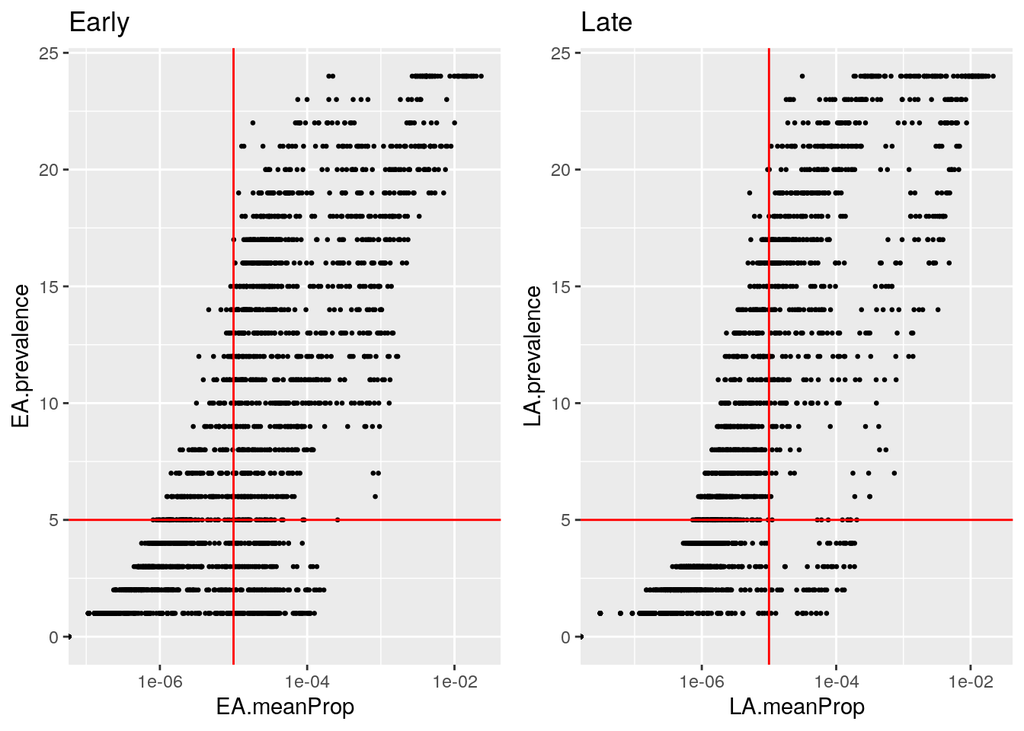

```r
# Per isoline:
EA.prop <- t(apply(EA, 1, function(x) x / sum(x)))
LA.prop <- t(apply(LA, 1, function(x) x / sum(x)))

# Abundance per replicate:
Ar <- SeqTabNoChim
rm(SeqTabNoChim)
Ar.prop <- t(apply(Ar, 1, function(x) x/sum(x)))
Sample.filter <- rowSums(Ar) >= 3000

# Data frame of amplicon traits, available for use with picante package.
Traits <- data.frame(
  meanProp = apply(Ar.prop[Sample.filter,], 2, mean),
  prevalence = colSums(Ar[Sample.filter,] > 0),
  EA.meanProp = apply(EA.prop, 2, mean),
  LA.meanProp = apply(LA.prop, 2, mean),
  EA.prevalence = colSums(EA > 0),
  LA.prevalence = colSums(LA > 0)
)

MinProp <- 1.0e-5
MinPrev <- 5
ASV.filter <- Traits$meanProp >= MinProp & Traits$prevalence >= MinPrev

p1 <- ggplot(Traits, aes(x=EA.meanProp, y=EA.prevalence)) +
  geom_point(size=0.5) + scale_x_log10() + ggtitle('Early') +
  geom_vline(xintercept=MinProp, color='red') + geom_hline(yintercept=MinPrev, color='red')
p2 <- ggplot(Traits, aes(x=LA.meanProp, y=LA.prevalence)) +
  geom_point(size=0.5) + scale_x_log10() + ggtitle('Late') +
  geom_vline(xintercept=MinProp, color='red') + geom_hline(yintercept=MinPrev, color='red')
grid.arrange(p1, p2, nrow=1)
```

```r
EA.filter <- Traits$EA.meanProp >= MinProp & Traits$EA.prevalence >= MinPrev
LA.filter <- Traits$LA.meanProp >= MinProp & Traits$LA.prevalence >= MinPrev

rm(p1,p2,MinProp,MinPrev)
```

## Alignment

Aligning only filtered sequences:

```r
if (file.exists('alignment.RData')) {
   load('alignment.RData')
} else {
   AmpFilt <- sort(colnames(Ar)[ASV.filter])
   alignment <- AlignSeqs(RNAStringSet(dna[AmpFilt]))
   BrowseSeqs(alignment, htmlFile='alignment.html', openURL=FALSE)
   save(alignment, file='alignment.RData')
   # Forces removal of tree upon update of alignment:
   if (file.exists('fitGTR.RData')) file.remove('fitGTR.RData')
}
```

[output not shown]

## Phylogenetic tree

```r
if (file.exists('fitGTR.RData')) {
   load('fitGTR.RData')
} else {
   library(phangorn)
   phang.align <- phyDat(as(DNAStringSet(alignment), "matrix"), type="DNA")
   dm <- dist.ml(phang.align)
   treeNJ <- NJ(dm) # Note, tip order != sequence order
   fit = pml(treeNJ, data=phang.align)

   fitGTR <- update(fit, k=4, inv=0.2)
   fitGTR <- optim.pml(fitGTR, model="GTR", optInv=TRUE, optGamma=TRUE,
                      rearrangement = "stochastic", control = pml.control(trace = 0))
   detach("package:phangorn", unload=TRUE) # avoids name clashes
   save(fitGTR, file='fitGTR.RData')
}
```

The tree object, of class `phylo`, is in `fitGTR$tree`. I am discovering the possibilities of the `picante` package. I will add taxonomy information to the `Traits` data frame, in case I use it later.

```r
Traits$Phylum  <- taxa[match(rownames(Traits), rownames(taxa)), 'Phylum']
Traits$Class   <- taxa[match(rownames(Traits), rownames(taxa)), 'Class']
Traits$Order   <- taxa[match(rownames(Traits), rownames(taxa)), 'Order']
Traits$Family  <- taxa[match(rownames(Traits), rownames(taxa)), 'Family']
Traits$Genus   <- taxa[match(rownames(Traits), rownames(taxa)), 'Genus']
Traits$Species <- taxa[match(rownames(Traits), rownames(taxa)), 'Species']
```

## Life history traits

The matrix `LH` contains the 10 original life-history trait variables, in their original scales, with isoline number as row names. I will make standardized version for later use, without modifying the original.

```r
LHc <- apply(LH, 2, function(x) (x - mean(x, na.rm=TRUE)) / sd(x, na.rm=TRUE))
LHc.imp <- mice(LHc, m=10)
LH.all <- complete(LHc.imp, action='all')
validIsolines  <- row.names(EA)
validVariables <- c('CSearly', 'CSSlope', 'EarlyRS', 'Rsen', 'AvLF', 'ActuarialB')
LH.all <- lapply(LH.all, function(x, f1=validIsolines, f2=validVariables) x[f1, f2])
```

# Diversity

Diversity measures can be analysed by replicate, rather than by isoline. We use better the information that way. But I need isoline-level measures of diversity as well, to correlate with life-history traits.

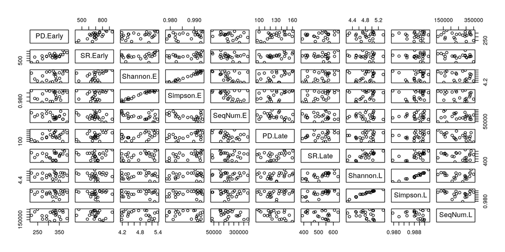

```r
## By isoline
#  ==========
#
# I make two d.f. and then bind them either by column or by row, to
# make the wide and long versions, for plotting.
Diversity.Early <- data.frame(
  isoline   = rownames(EA),
  PD.Early  = pd(EA[,EA.filter], fitGTR$tree, include.root = FALSE)[,1],
  SR.Early  = pd(EA[,EA.filter], fitGTR$tree, include.root = FALSE)[,2],
  Shannon.E = diversity(EA[,EA.filter], index='shannon'),
  Simpson.E = diversity(EA[,EA.filter], index='simpson'),
  SeqNum.E  = rowSums(EA[,EA.filter]),
  batch     = sapply(split(SampleData, SampleData$isoline),
                function(x) sum(x$seqrun == 2) / length(x$seqrun))
)

Diversity.Late <- data.frame(
  isoline   = rownames(LA),
  PD.Late   = pd(LA[,LA.filter], fitGTR$tree, include.root = FALSE)[,1],
  SR.Late   = pd(LA[,LA.filter], fitGTR$tree, include.root = FALSE)[,2],
  Shannon.L = diversity(LA[,LA.filter], index='shannon'),
  Simpson.L = diversity(LA[,LA.filter], index='simpson'),
  SeqNum.L  = rowSums(LA[,LA.filter]),
  batch     = sapply(split(SampleData, SampleData$isoline),
                function(x) sum(x$seqrun == 2) / length(x$seqrun))
)

DiverIso.wide <- cbind(Diversity.Early[,-7], Diversity.Late[,-1])
names(Diversity.Early) <- c('isoline','PD','SR','Shannon','Simpson','SeqNum','batch')
names(Diversity.Late)  <- c('isoline','PD','SR','Shannon','Simpson','SeqNum','batch')
Diversity.Early$age <- factor('Early', levels=c('Early','Late'))
Diversity.Late$age  <- factor('Late', levels=c('Early','Late'))
DiverIso.long <- rbind(Diversity.Early, Diversity.Late)

# I remove the SeqNum (sequencing effort) for sample 29, late, just for plotting.
z <- DiverIso.wide['29', 'SeqNum.L']
DiverIso.wide['29', 'SeqNum.L'] <- NA
pairs(DiverIso.wide[,c(2:11)])
```

```r
DiverIso.wide['29', 'SeqNum.L'] <- z
rm(z, Diversity.Early, Diversity.Late)

## Per replicate
#  =============
DiverRep.long <- data.frame(
  isoline = SampleData$isoline,
  age     = SampleData$age,
  PD      = numeric(length = nrow(Ar)),
  SR      = numeric(length = nrow(Ar)),
  Shannon = numeric(length = nrow(Ar)),
  Simpson = numeric(length = nrow(Ar)),
  SeqNum  = numeric(length = nrow(Ar)),
  batch   = SampleData$seqrun
)
isEarly <- DiverRep.long$age %in% 'Early'
isLate  <- DiverRep.long$age %in% 'Late'
DiverRep.long[isEarly, 'PD'] <- pd(Ar[isEarly, EA.filter], fitGTR$tree, include.root=FALSE)[,1]
DiverRep.long[isLate,  'PD'] <- pd(Ar[isLate,  LA.filter], fitGTR$tree, include.root=FALSE)[,1]
DiverRep.long[isEarly, 'SR'] <- pd(Ar[isEarly, EA.filter], fitGTR$tree, include.root=FALSE)[,2]
DiverRep.long[isLate,  'SR'] <- pd(Ar[isLate,  LA.filter], fitGTR$tree, include.root=FALSE)[,2]
DiverRep.long[isEarly, 'Shannon'] <- diversity(Ar[isEarly, EA.filter], index='shannon')
DiverRep.long[isLate,  'Shannon'] <- diversity(Ar[isLate,  LA.filter], index='shannon')
DiverRep.long[isEarly, 'Simpson'] <- diversity(Ar[isEarly, EA.filter], index='simpson')
DiverRep.long[isLate,  'Simpson'] <- diversity(Ar[isLate,  LA.filter], index='simpson')
DiverRep.long[isEarly, 'SeqNum'] <- rowSums(Ar[isEarly, EA.filter])
DiverRep.long[isLate,  'SeqNum'] <- rowSums(Ar[isLate, EA.filter])
```

Species richness (`SR.Early` and `SR.Late`) is correlated with phylogenetic distance (`PD.Early` and `PD.Late`), but not with sequencing effort (`SeqNum`). Measures of diversity late in life are not visibly correlated with those early in life.

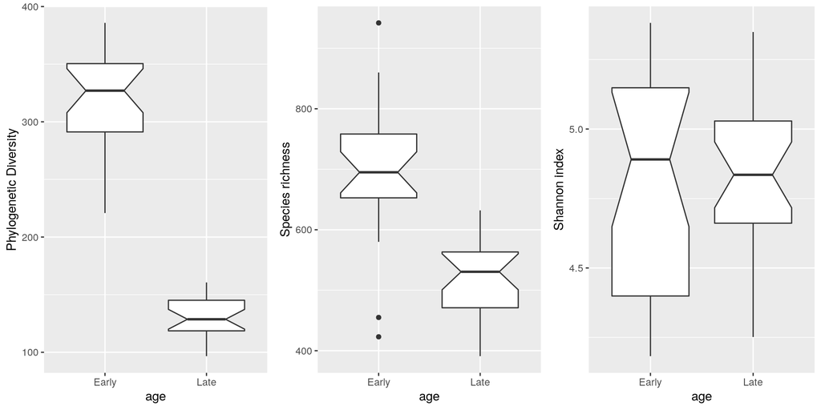

```r
p1 <- ggplot(DiverIso.long, aes(x=age, y=PD)) + geom_boxplot(notch=TRUE) + ylab('Phylogenetic Diversity')
p2 <- ggplot(DiverIso.long, aes(x=age, y=SR)) + geom_boxplot(notch=TRUE) + ylab('Species richness')
p3 <- ggplot(DiverIso.long, aes(x=age, y=Simpson)) + geom_boxplot(notch=TRUE) + ylab('Simpson index')
p4 <- ggplot(DiverIso.long, aes(x=age, y=Shannon)) + geom_boxplot(notch=TRUE) + ylab('Shannon index')
grid.arrange(p1,p2,p4, nrow=1)
```

```r
rm(p1, p2, p3, p4)
```

The plot above shows roughly an effect of age on diversity, that Pau Carazo had reported previously, using slightly different data (different amplicon filters, and indices estimated with a different package). What we didn't know is that the effect is so much more accused when using Faith's phylogenetic diversity. In a model:

```r
m1 <- lmer(PD ~ age + (age|isoline) + (1|batch), data=DiverRep.long)
```

```
## boundary (singular) fit: see ?isSingular
```

```r
summary(m1)
```

```
## Linear mixed model fit by REML ['lmerMod']
## Formula: PD ~ age + (age | isoline) + (1 | batch)
##    Data: DiverRep.long
##
## REML criterion at convergence: 1738.7
##
## Scaled residuals:
##     Min      1Q  Median      3Q     Max
## -4.7021 -0.3669 -0.0473  0.4442  3.6474
##
## Random effects:
##  Groups   Name        Variance Std.Dev. Corr
##  isoline  (Intercept) 1030.00  32.094
##           ageLate      805.75  28.386   -1.00
##  batch    (Intercept)   27.29   5.224
##  Residual              923.53  30.390
## Number of obs: 177, groups:  isoline, 24; batch, 2
##
## Fixed effects:
##             Estimate Std. Error t value
## (Intercept)  213.716      8.207   26.04
## ageLate     -113.097      7.389  -15.30
##
## Correlation of Fixed Effects:
##         (Intr)
## ageLate -0.803
## convergence code: 0
## boundary (singular) fit: see ?isSingular
```

```r
anova(m1)
```

```
## Analysis of Variance Table
##     npar Sum Sq Mean Sq F value
## age    1 216343  216343  234.26
```

Among the amplicons with a significant fold change in `2020-03-17` there are several *Acetobacter* and some *Lactobacillus*.

# Redundancy analysis

Much can be improved from the first redundancy analysis performed on `2020-04-13`. Little variance in life-history traits could be explained by the main axes of variation in amplicon abundance. A wiser selection of explanatory variables could help compensate the noise and the high dimensionality in abundance data. I recall Pau Carazo's multiple linear regression analyses were more successful than my redundancy analysis. He found some effects of two ordination axes of abundance data on two out of three principal components of life-history variable. Neither diversity (Simpson index) nor *Lactobacillus* to *Acetobacter* abundance ratio made any important contributions to Pau's models.

## Diversity and significant change

Here I will use phylogenetic diversity and abundances of only some of the amplicons with the most significant fold change of abundance between early and late samples, as determined in `2020-03-17`. From those results, data frame `sigtab` contains the 139 most significant amplicons, belonging to 4 genera and 2 phyla.

```r
sigtab$amplicon <- rownames(sigtab)
# Need to remmove names attribute of variables in sigtab. Didn't find a way
# to avoid a loop!
for (var in colnames(sigtab)) {
  names(sigtab[,deparse(as.name(var))]) <- NULL
}
MaxDifPerGenus <- ddply(sigtab, .(Genus), function(x) head(x[order(x$padj),], n=1))
MaxDifPerGenus[,-c(7,10,13)]
```

```
##       baseMean log2FoldChange     lfcSE       stat       pvalue         padj
## 1 0.0095158302       3.845062 0.2763509  13.913694 5.230631e-44 3.959588e-41
## 2 0.0001220930       2.391049 0.8356375   2.861348 4.218443e-03 2.419213e-02
## 3 0.0036463870      -3.945747 0.3266705 -12.078677 1.369051e-33 5.181856e-32
## 4 0.0001835658      -3.160776 0.5771797  -5.476243 4.344498e-08 3.654206e-07
##           Phylum               Class           Family         Genus amplicon
## 1 Proteobacteria Alphaproteobacteria Acetobacteraceae   Acetobacter    A0018
## 2     Firmicutes             Bacilli Lactobacillaceae Lactobacillus    A0593
## 3 Proteobacteria Gammaproteobacteria Burkholderiaceae     Ralstonia    A0157
## 4 Proteobacteria Gammaproteobacteria Pseudomonadaceae   Pseudomonas    A0566
```

```r
# Using only late abundance for all amplicons, irrespective of fold change:
z1 <- LA.prop[, MaxDifPerGenus[MaxDifPerGenus$log2FoldChange < 0, 'amplicon']]
z2 <- LA.prop[, MaxDifPerGenus[MaxDifPerGenus$log2FoldChange > 0, 'amplicon']]
z1 <- z1[, colnames(z1) %in% colnames(LA)[LA.filter]]
z2 <- z2[, colnames(z2) %in% colnames(LA)[LA.filter]]
colnames(z1) <- paste0('L', colnames(z1))
colnames(z2) <- paste0('L', colnames(z2))
Selected <- cbind(z1, z2)

Predictors <- as.data.frame(log10(Selected + 1.0e-07))
Predictors$PD.Early <- DiverIso.wide$PD.Early
Predictors$PD.Late  <- DiverIso.wide$PD.Late
Predictors$Simpson.E <- DiverIso.wide$Simpson.E
Predictors$Simpson.L <- DiverIso.wide$Simpson.L
batch <- sapply(split(SampleData, SampleData$isoline),
                function(x) sum(x$seqrun == 2) / length(x$seqrun))
all.equal(names(batch), rownames(Predictors))
```

```
## [1] TRUE
```

```r
RDA0    <- lapply(LH.all, function(lh) rda(lh ~ Condition(batch),
                                        data = Predictors))
RDA18  <- lapply(LH.all, function(lh) rda(lh ~ . + Condition(batch),
                                           data = Predictors))
RDA18.anova <- lapply(RDA18, anova)
sapply(RDA18.anova, function(x) x$'Pr(>F)'[1])
```

```
##     1     2     3     4     5     6     7     8     9    10
## 0.654 0.649 0.642 0.706 0.733 0.716 0.682 0.739 0.685 0.691
```

```r
#RDA  <- lapply(RDA0, function(x) ordistep(x, RDA18[[1]], Pin=0.1, Pout=0.15, steps=100, trace=FALSE))
#lapply(RDA, function(x) x$terms[[3]])
```

## Biodiversity and significant change, with PCA

```r
# Use the amplicons in significant results (sigtab) as a filter for abundance data
F <- rownames(sigtab)
z1 <- EA.prop[,F]
z2 <- LA.prop[,F]
colnames(z1) <- paste0('E', colnames(z1))
colnames(z2) <- paste0('L', colnames(z1))
A <- cbind(z1,z2)
A.sq <- apply(A, 2, skewness)
B <- A[,abs(A.sq) <= 0.25]   # not transformed
C <- sqrt(A[,abs(A.sq) >  0.25 & abs(A.sq) <= 1.0])  # sqrt-transformed
D <- log10(A[,abs(A.sq) >  1.0] + 1.0e-07)   # log-transformed
colnames(C) <- paste0('sqrt.',colnames(C))
colnames(D) <- paste0('log.', colnames(D))
AT <- cbind(B,C,D)
AT <- AT[, abs(apply(AT,2,skewness)) < 2]
AT.cov <- cov.wt(AT)
AT.pca <- princomp(AT, covmat = AT.cov, scores = TRUE)
stopifnot(all.equal(rownames(AT.pca$scores), rownames(DiverIso.wide)))
Predictors <- cbind(DiverIso.wide[,c('PD.Early','PD.Late','Simpson.E','Simpson.L')],
                    AT.pca$scores[,1:17])
RDA0 <- lapply(LH.all, function(lh) rda(lh ~ Condition(batch),
                                        data = Predictors))
RDAX <- lapply(LH.all, function(lh) rda(lh ~ . + Condition(batch),
                                        data = Predictors))
RDAX.aov <- lapply(RDAX, anova)
sapply(RDAX.aov, function(x) x$'Pr(>F)'[1])
```

```
##     1     2     3     4     5     6     7     8     9    10
## 0.026 0.067 0.017 0.018 0.014 0.011 0.014 0.089 0.023 0.011
```

```r
#RDA <- lapply(RDA0, function(x) ordistep(x, RDAX[[1]], Pin=0.1, Pout=0.15, steps=100, trace=FALSE))
#lapply(RDA, function(x) x$terms[[3]])
```

## Diversity and genus

Here I use as predictor variables the abundances of the most frequent genera either early or late, and diversity measures.

```r
z <- as.data.frame(t(EA.prop[,EA.filter | LA.filter]))
z$Genus <- taxa[rownames(z),'Genus']
sum(is.na(z$Genus))
```

```
## [1] 29
```

```r
GenPropE <- sapply(split(z[,1:24], z$Genus), function(x) colSums(x))
GeneraE <- names(sort(colSums(GenPropE), decreasing=TRUE)[1:19])

z <- as.data.frame(t(LA.prop[,EA.filter | LA.filter]))
z$Genus <- taxa[rownames(z), 'Genus']
sum(is.na(z$Genus))
```

```
## [1] 29
```

```r
GenPropL <- sapply(split(z[,1:24], z$Genus), function(x) colSums(x))
GeneraL <- names(sort(colSums(GenPropL), decreasing=TRUE)[1:19])

stopifnot(all.equal(rownames(GenPropL), rownames(DiverIso.wide)),
          all.equal(rownames(GenPropE), rownames(DiverIso.wide)))
PredictorsE <- as.data.frame(cbind(PD.Early = DiverIso.wide$PD.Early,
                                   Simpson.E = DiverIso.wide$Simpson.E,
                                   log10(GenPropE[,colnames(GenPropE) %in% GeneraE] + 1.0e-6)))
PredictorsE <- PredictorsE[, abs(sapply(PredictorsE, skewness)) < 1.5]
names(PredictorsE) <- paste0(names(PredictorsE), '.E')
PredictorsL <- as.data.frame(cbind(PD.Late = DiverIso.wide$PD.Late,
                                   Simpson.L = DiverIso.wide$Simpson.L,
                                   log10(GenPropL[,colnames(GenPropL) %in% GeneraL] + 1.0e-6)))
PredictorsL <- PredictorsL[, abs(sapply(PredictorsL, skewness)) < 1.5]
names(PredictorsL) <- paste0(names(PredictorsL), '.L')
RDA0 <- lapply(LH.all, function(lh) rda(lh ~ Condition(batch),
                                        data = PredictorsL))
RDAX <- lapply(LH.all, function(lh) rda(lh ~ . + Condition(batch),
                                        data = PredictorsL))
RDAX.anova <- lapply(RDAX, anova)
sapply(RDAX.anova, function(x) x$'Pr(>F)'[1])
```

```
##     1     2     3     4     5     6     7     8     9    10
## 0.563 0.607 0.530 0.601 0.605 0.574 0.544 0.699 0.623 0.559
```

```r
RDA  <- lapply(RDA0, function(x) ordistep(x, RDAX[[1]], Pin=0.1, Pout=0.15, steps=100, trace=FALSE))
```

```r
lapply(RDA, function(x) x$terms[[3]])
```

```
## $`1`
## Condition(batch)
##
## $`2`
## Condition(batch)
##
## $`3`
## Condition(batch)
##
## $`4`
## Condition(batch)
##
## $`5`
## Condition(batch)
##
## $`6`
## Condition(batch)
##
## $`7`
## Condition(batch)
##
## $`8`
## Condition(batch)
##
## $`9`
## Condition(batch)
##
## $`10`
## Condition(batch)
```

# Class

```r
z <- as.data.frame(t(EA.prop[,EA.filter | LA.filter]))
z$Class <- taxa[rownames(z),'Class']
sum(is.na(z$Class))
```

```
## [1] 0
```

```r
ClassPropE <- sapply(split(z[,1:24], z$Class), function(x) colSums(x))
ClassE <- names(sort(colSums(ClassPropE), decreasing=TRUE))

z <- as.data.frame(t(LA.prop[,EA.filter | LA.filter]))
z$Class <- taxa[rownames(z), 'Class']
sum(is.na(z$Class))
```

```
## [1] 0
```

```r
ClassPropL <- sapply(split(z[,1:24], z$Class), function(x) colSums(x))
ClassL <- names(sort(colSums(ClassPropL), decreasing=TRUE)[1:19])

stopifnot(all.equal(rownames(ClassPropL), rownames(DiverIso.wide)),
          all.equal(rownames(ClassPropE), rownames(DiverIso.wide)))
PredictorsE <- as.data.frame(cbind(PD.Early = DiverIso.wide$PD.Early,
                                   Simpson.E = DiverIso.wide$Simpson.E,
                                   log10(ClassPropE[,colnames(ClassPropE) %in% ClassE] + 1.0e-7)))
PredictorsE <- PredictorsE[, abs(sapply(PredictorsE, skewness)) < 1.5]
names(PredictorsE) <- paste0(names(PredictorsE), '.E')
PredictorsL <- as.data.frame(cbind(PD.Late = DiverIso.wide$PD.Late,
                                   Simpson.L = DiverIso.wide$Simpson.L,
                                   log10(ClassPropL[,colnames(ClassPropL) %in% ClassL] + 1.0e-7)))
#PredictorsL <- PredictorsL[, abs(sapply(PredictorsL, skewness)) < 1.5]
names(PredictorsL) <- paste0(names(PredictorsL), '.L')
RDA0 <- lapply(LH.all, function(lh) rda(lh ~ Condition(batch),
                                        data = PredictorsL))
RDAX <- lapply(LH.all, function(lh) rda(lh ~ . + Condition(batch),
                                        data = PredictorsL))
RDAX.anova <- lapply(RDAX, anova)
sapply(RDAX.anova, function(x) x$'Pr(>F)'[1])
```

```
##     1     2     3     4     5     6     7     8     9    10
## 0.912 0.907 0.905 0.938 0.933 0.941 0.903 0.958 0.942 0.928
```

```r
#RDA  <- lapply(RDA0, function(x) ordistep(x, RDAX[[1]], Pin=0.1, Pout=0.15, steps=100, trace=FALSE))
#lapply(RDA, function(x) x$terms[[3]])
```

## Strong abundance filter and diversity

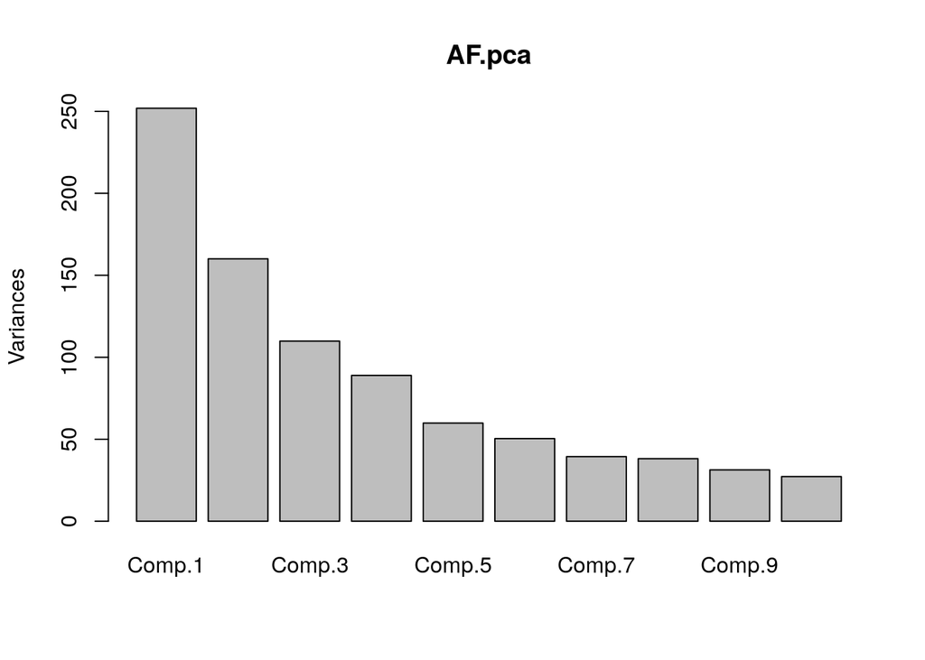

```r
F <- Traits$EA.meanProp >= 1.0e-04 & Traits$LA.meanProp >= 1.0e-04
z1 <- EA.prop[,F]
z2 <- LA.prop[,F]
colnames(z1) <- paste0('E', colnames(z1))
colnames(z2) <- paste0('L', colnames(z2))
AF <- cbind(z1,z2)
AF.log <- log10(AF + 1.0e-07)
AF.log.n <- AF.log[, abs(apply(AF.log,2,skewness)) <= 1.5]
AF.log.cov <- cov.wt(AF.log.n)
AF.pca <- princomp(AF.log.n, covmat=AF.log.cov, scores=TRUE)
plot(AF.pca)
```

```r
Predictors <- cbind(DiverIso.wide[,c('PD.Early','PD.Late','Simpson.E','Simpson.L')],
                    AF.pca$scores[,1:17])
RDA0 <- lapply(LH.all, function(lh) rda(lh ~ Condition(batch), data=Predictors))
RDAX <- lapply(LH.all, function(lh) rda(lh ~ . + Condition(batch), data=Predictors[,1:17]))
RDAX.aov <- lapply(RDAX, anova)
sapply(RDAX.aov, function(x) x$'Pr(>F)'[1])
```

```
##     1     2     3     4     5     6     7     8     9    10
## 0.470 0.530 0.396 0.386 0.453 0.413 0.364 0.583 0.482 0.390
```

```r
RDA  <- lapply(RDA0, function(x) ordistep(x, RDAX[[1]], Pin=0.1, Pout=0.15, steps=100, trace=FALSE))
```

```r
lapply(RDA, function(x) x$terms[[3]])
```

```
## $`1`
## Condition(batch) + Comp.7
##
## $`2`
## Condition(batch) + Comp.7 + Comp.1
##
## $`3`
## Condition(batch)
##
## $`4`
## Condition(batch) + Comp.7
##
## $`5`
## Condition(batch) + Comp.7
##
## $`6`
## Condition(batch) + Comp.7
##
## $`7`
## Condition(batch)
##
## $`8`
## Condition(batch) + Comp.7
##
## $`9`
## Condition(batch) + Comp.7
##
## $`10`
## Condition(batch) + Comp.7 + Comp.3
```

```r
#RDA.aov <- lapply(RDA, anova)
#sapply(RDA.aov, function(x) x$'Pr(>F)'[1])
```

# Conclusions

```r
save(SampleData, EA, LA, EA.prop, LA.prop, Ar, Ar.prop, Traits, EA.filter, LA.filter, fitGTR, DiverIso.wide, DiverIso.long, DiverRep.long, sigtab, taxa, file='Diversity.RData')
```

# References

Callahan, B.J., K. Sankaran, J.A. Fukuyama, P.J. McMurdie, and S.P. Holmes. 2016. “Bioconductor Workflow for Microbiome Data Analysis: From Raw Reads to Community Analyses.” *F1000Research* 5: 1492. doi:https://doi.org/10.12688/f1000research.8986.2.